# Analyse de données - *correction*

```python
import numpy
import pandas
import matplotlib.pyplot as plt
import seaborn
seaborn.set_style("white")

%matplotlib inline
```

## ACP

Nous allons travailler ici sur les données de température mondiale HadCRUT4, fournies par [Climate Research Unit](https://crudata.uea.ac.uk/). Vous trouverez plus d’informations sur ces données sur ce [lien](https://crudata.uea.ac.uk/cru/data/temperature/). Nous avons ici l’historique des anomalies moyennes mensuelles et annuelles depuis 1850, au niveau mondial, par rapport à la période 1961-1990.

```python
had = pandas.read_csv("https://crudata.uea.ac.uk/cru/data/temperature/HadCRUT4-gl.dat", header=None)
donnees = pandas.DataFrame(
    [list(map(lambda v: float(v), filter(lambda v: v!= "", h.split(" ")))) for h in had[0][::2]],
    columns = ["Year", "Jan", "Feb", "Mar", "Apr", "May", "Jun", "Jul", "Aug", "Sep", "Oct", "Nov", "Dec", "Annual"]
)
# suppression année 2020 (incomplète)
donnees = donnees.loc[:(len(donnees)-2)]
donnees.tail()
```

|  | Year | Jan | Feb | Mar | Apr | May | Jun | Jul | Aug | Sep | Oct | Nov | Dec | Annual |
| --- | --- | --- | --- | --- | --- | --- | --- | --- | --- | --- | --- | --- | --- | --- |
| 165 | 2015.0 | 0.705 | 0.689 | 0.708 | 0.673 | 0.711 | 0.743 | 0.697 | 0.740 | 0.796 | 0.845 | 0.840 | 1.024 | 0.763 |
| 166 | 2016.0 | 0.934 | 1.111 | 1.106 | 0.937 | 0.707 | 0.744 | 0.744 | 0.790 | 0.729 | 0.598 | 0.553 | 0.620 | 0.797 |
| 167 | 2017.0 | 0.739 | 0.845 | 0.873 | 0.737 | 0.659 | 0.641 | 0.651 | 0.714 | 0.557 | 0.571 | 0.554 | 0.600 | 0.677 |
| 168 | 2018.0 | 0.554 | 0.528 | 0.615 | 0.627 | 0.587 | 0.573 | 0.594 | 0.586 | 0.598 | 0.678 | 0.590 | 0.638 | 0.597 |
| 169 | 2019.0 | 0.738 | 0.662 | 0.874 | 0.780 | 0.610 | 0.708 | 0.706 | 0.719 | 0.713 | 0.752 | 0.693 | 0.880 | 0.736 |

Vous devez donc réaliser les étapes suivantes :

- Décrire rapidement les données
- Réaliser une ACP centrée ou normée (choix à justifier), sur les données mensuelles
- Ajouter la moyenne annuelle en variable supplémentaire
- Produire les graphiques nécessaires à l’interprétation
- Identifier des années particulières
  - Refaire l’ACP en les indiquant comme individus supplémentaires
  - Comparer les résultats pour voir s’il est opportun ou non de les garder dans l’analyse
- Que peut-on dire globalement ?

### Description des données

```python
numpy.round(donnees.describe(), 2)
```

|  | Year | Jan | Feb | Mar | Apr | May | Jun | Jul | Aug | Sep | Oct | Nov | Dec | Annual |
| --- | --- | --- | --- | --- | --- | --- | --- | --- | --- | --- | --- | --- | --- | --- |
| count | 170.00 | 170.00 | 170.00 | 170.00 | 170.00 | 170.00 | 170.00 | 170.00 | 170.00 | 170.00 | 170.00 | 170.00 | 170.00 | 170.00 |
| mean | 1934.50 | -0.09 | -0.09 | -0.13 | -0.09 | -0.10 | -0.07 | -0.05 | -0.04 | -0.07 | -0.08 | -0.11 | -0.12 | -0.09 |
| std | 49.22 | 0.36 | 0.37 | 0.37 | 0.34 | 0.31 | 0.30 | 0.29 | 0.30 | 0.30 | 0.32 | 0.34 | 0.35 | 0.31 |
| min | 1850.00 | -0.97 | -0.78 | -0.83 | -0.72 | -0.77 | -0.58 | -0.57 | -0.70 | -0.56 | -0.71 | -0.77 | -0.89 | -0.54 |
| 25% | 1892.25 | -0.32 | -0.35 | -0.40 | -0.34 | -0.32 | -0.28 | -0.25 | -0.25 | -0.28 | -0.32 | -0.37 | -0.36 | -0.30 |
| 50% | 1934.50 | -0.11 | -0.15 | -0.21 | -0.17 | -0.17 | -0.14 | -0.10 | -0.09 | -0.11 | -0.11 | -0.13 | -0.17 | -0.16 |
| 75% | 1976.75 | 0.12 | 0.14 | 0.07 | 0.09 | 0.07 | 0.07 | 0.05 | 0.08 | 0.07 | 0.07 | 0.04 | 0.13 | 0.05 |
| max | 2019.00 | 0.93 | 1.11 | 1.11 | 0.94 | 0.71 | 0.74 | 0.74 | 0.79 | 0.80 | 0.84 | 0.84 | 1.02 | 0.80 |

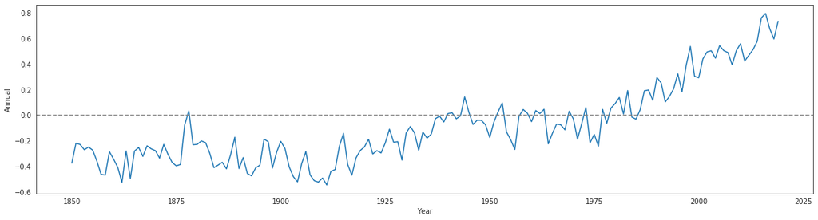

```python
plt.figure(figsize=(20,5))
ax = seaborn.lineplot(x = "Year", y = "Annual", data = donnees)
ax.axhline(0, color = "gray", ls = "--")
plt.show()
```

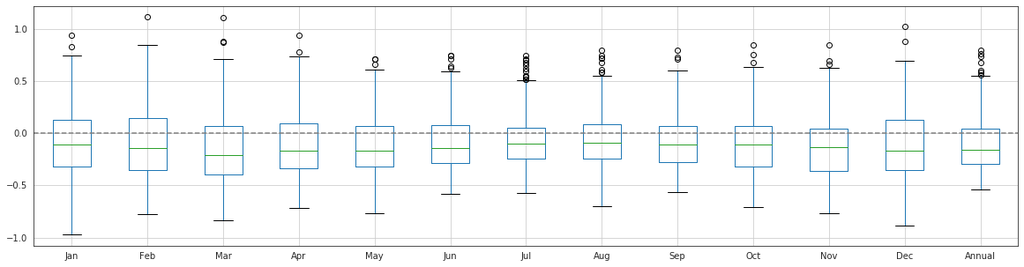

```python
plt.figure(figsize=(20,5))
ax = donnees.drop(columns = "Year").boxplot()
ax.axhline(0, ls = "--", color = "gray")
plt.show()
```

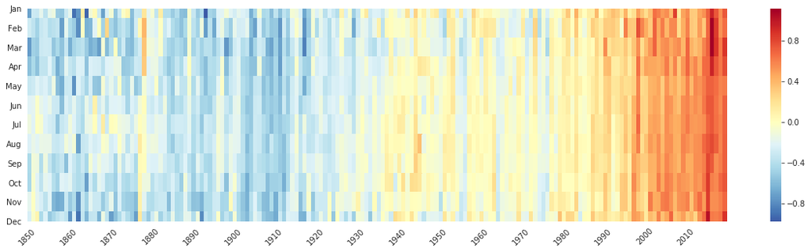

```python
plt.figure(figsize=(20,5))
seaborn.heatmap(donnees.drop(columns = ["Year", "Annual"]).T,
                center = 0, cmap = "RdYlBu_r")
plt.xticks([10 * e for e in range(17)],
           [int(a) for a in donnees.Year if (a % 10) == 0],
           rotation = 45)
plt.yticks(rotation=0)
plt.show()
```

### ACP

```python
from sklearn.decomposition import PCA
from sklearn.preprocessing import scale

pca = PCA()
pca.fit(donnees.drop(columns = ["Year", "Annual"]))
```

```
PCA(copy=True, iterated_power='auto', n_components=None, random_state=None,
    svd_solver='auto', tol=0.0, whiten=False)
```

```python
eig = pandas.DataFrame(
    {
        "Dimension" : ["Dim" + str(x + 1) for x in range(12)],
        "Valeur propre" : pca.explained_variance_,
        "% variance expliquée" : numpy.round(pca.explained_variance_ratio_ * 100),
        "% cum. var. expliquée" : numpy.round(numpy.cumsum(pca.explained_variance_ratio_) * 100)
    },
    columns = ["Dimension", "Valeur propre", "% variance expliquée", "% cum. var. expliquée"]
)
eig
```

|  | Dimension | Valeur propre | % variance expliquée | % cum. var. expliquée |
| --- | --- | --- | --- | --- |
| 0 | Dim1 | 1.145376 | 88.0 | 88.0 |
| 1 | Dim2 | 0.058189 | 4.0 | 92.0 |
| 2 | Dim3 | 0.024330 | 2.0 | 94.0 |
| 3 | Dim4 | 0.018201 | 1.0 | 96.0 |
| 4 | Dim5 | 0.014051 | 1.0 | 97.0 |
| 5 | Dim6 | 0.012941 | 1.0 | 98.0 |
| 6 | Dim7 | 0.008060 | 1.0 | 98.0 |
| 7 | Dim8 | 0.007750 | 1.0 | 99.0 |
| 8 | Dim9 | 0.004904 | 0.0 | 99.0 |
| 9 | Dim10 | 0.003736 | 0.0 | 99.0 |
| 10 | Dim11 | 0.003498 | 0.0 | 100.0 |
| 11 | Dim12 | 0.003214 | 0.0 | 100.0 |

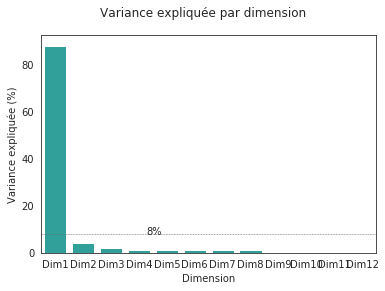

```python
g_eig = seaborn.barplot(x = "Dimension",
                y = "% variance expliquée",
                palette = ["lightseagreen"],
                data = eig)
g_eig.set(ylabel = "Variance expliquée (%)")
g_eig.figure.suptitle("Variance expliquée par dimension")
plt.axhline(y = 8, linewidth = .5, color = "dimgray", linestyle = "--") # 8 = 100 / 12 (nb dimensions)
plt.text(3.25, 8, "8%")
```

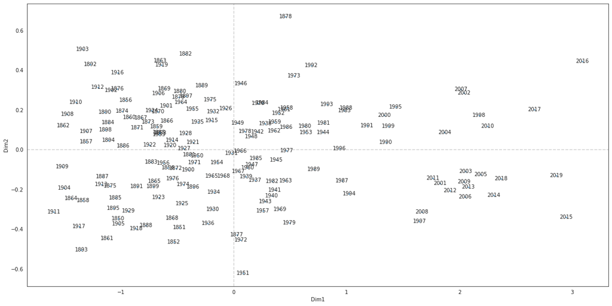

```python
donnees_pca = pca.transform(donnees.drop(columns = ["Year", "Annual"]))
# Transformation en DataFrame pandas
donnees_pca_df = pandas.DataFrame({
    "Dim1" : donnees_pca[:,0],
    "Dim2" : donnees_pca[:,1],
    "Year" : pandas.to_numeric(donnees.Year)
})

# Résultat (premières lignes)
plt.figure(figsize = (20, 10))
g_pca = seaborn.regplot("Dim1", "Dim2", data = donnees_pca_df, fit_reg=False,
                        scatter_kws={'s':2})
for i in range(donnees_pca_df.shape[0]):
    #if (donnees_pca_df.Dim1[i] > 1.5):
    g_pca.text(donnees_pca_df.Dim1[i], donnees_pca_df.Dim2[i],
               int(donnees_pca_df.Year[i]),
               horizontalalignment='center',
               verticalalignment='center')
g_pca.axhline(0, ls="--", color="lightgray")
g_pca.axvline(0, ls="--", color="lightgray")
#g_pca.fig.suptitle("Premier plan factoriel")
plt.show()
```

## DBSCAN

La banque mondiale fournit un grand nombre de données, dont des indicateurs de gouvernance au niveau mondial (voir [ici](https://data.worldbank.org/data-catalog/worldwide-governance-indicators)). Le code ci-dessous importe les données du fichier WGI_Data.csv (que vous devez donc télécharger) pour les importer. Les informations concernant la définition des indicateurs et leur source se trouvent dans le fichier [WGI_Definition and Source.csv](https://fxjollois.github.io/cours-2017-2018/analyse-donnees/WGI_Definition%20and%20Source.csv).

```python
wgi_one = pandas.read_csv("WGI_Data.csv")
wgi_one.head()
```

|  | Country Name | Country Code | Series Name | Series Code | Value |
| --- | --- | --- | --- | --- | --- |
| 0 | Afghanistan | AFG | Control of Corruption: Estimate | CC.EST | -1.56373512744904 |
| 1 | Afghanistan | AFG | Government Effectiveness: Estimate | GE.EST | -1.2221063375473 |
| 2 | Afghanistan | AFG | Political Stability and Absence of Violence/Te... | PV.EST | -2.74916744232178 |
| 3 | Afghanistan | AFG | Regulatory Quality: Estimate | RQ.EST | -1.32791936397552 |
| 4 | Afghanistan | AFG | Rule of Law: Estimate | RL.EST | -1.61642956733704 |

```python
[s.replace(": Estimate", "") for s in wgi_one["Series Name"].unique()]
```

```
['Control of Corruption',
 'Government Effectiveness',
 'Political Stability and Absence of Violence/Terrorism',
 'Regulatory Quality',
 'Rule of Law',
 'Voice and Accountability']
```

```python
wgi_bis = wgi_one[["Country Name", "Series Code", "Value"]][wgi_one.Value != ".."]
wgi_ter = wgi_bis.astype({"Value": float})
wgi = wgi_ter.pivot_table(values = "Value", index = "Country Name", columns = "Series Code")
wgi.head()
```

| Series Code Country Name | CC.EST | GE.EST | PV.EST | RL.EST | RQ.EST | VA.EST |
| --- | --- | --- | --- | --- | --- | --- |
| Afghanistan | -1.563735 | -1.222106 | -2.749167 | -1.616430 | -1.327919 | -1.086220 |
| Albania | -0.397567 | -0.000573 | 0.257720 | -0.347468 | 0.188962 | 0.159191 |
| Algeria | -0.691359 | -0.544695 | -1.139282 | -0.849319 | -1.171843 | -0.877241 |
| American Samoa | 1.230341 | 0.531472 | 1.192534 | 1.328246 | 0.136647 | NaN |
| Andorra | 1.230341 | 1.860201 | 1.396047 | 1.564011 | 0.871409 | 1.197540 |

```python
wgi = wgi.dropna()
```

```python
wgi.describe()
```

| Series Code | CC.EST | GE.EST | PV.EST | RL.EST | RQ.EST | VA.EST |
| --- | --- | --- | --- | --- | --- | --- |
| count | 202.000000 | 202.000000 | 202.000000 | 202.000000 | 202.000000 | 202.000000 |
| mean | -0.036816 | -0.032889 | -0.041644 | -0.028521 | -0.026560 | -0.010150 |
| std | 0.995842 | 0.998423 | 1.000286 | 1.002046 | 1.003657 | 0.999537 |
| min | -1.813440 | -2.259862 | -2.914053 | -2.370821 | -2.331930 | -2.132314 |
| 25% | -0.752065 | -0.696937 | -0.623982 | -0.762459 | -0.738538 | -0.811747 |
| 50% | -0.271538 | -0.170732 | 0.045975 | -0.162339 | -0.171410 | 0.090408 |
| 75% | 0.671235 | 0.655952 | 0.815968 | 0.629157 | 0.653908 | 0.922974 |
| max | 2.295205 | 2.208584 | 1.961483 | 2.043331 | 2.180700 | 1.581641 |

### Classification

```python
from sklearn.cluster import DBSCAN

db = DBSCAN(eps = .8, min_samples = 3)
db.fit(wgi)
```

```
DBSCAN(algorithm='auto', eps=0.8, leaf_size=30, metric='euclidean',
       metric_params=None, min_samples=3, n_jobs=None, p=None)
```

```python
wgi_db = wgi.assign(Labels = db.labels_)
wgi_db.groupby("Labels").mean()
```

| Series Code Labels | CC.EST | GE.EST | PV.EST | RL.EST | RQ.EST | VA.EST |
| --- | --- | --- | --- | --- | --- | --- |
| -1 | -0.036795 | -0.055243 | 0.112498 | -0.053595 | -0.083211 | -0.576135 |
| 0 | -1.494299 | -1.685430 | -2.371651 | -1.723911 | -1.551087 | -1.491839 |
| 1 | -0.541357 | -0.464884 | -0.383015 | -0.482340 | -0.398705 | -0.242662 |
| 2 | 1.103227 | 1.046090 | 0.879165 | 1.098989 | 0.987419 | 1.040816 |
| 3 | -1.348473 | -1.490840 | -0.634753 | -1.572616 | -2.203282 | -2.119010 |

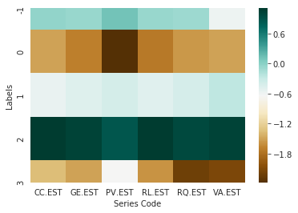

```python
seaborn.heatmap(wgi_db.groupby("Labels").mean(), cmap = "BrBG")
```

### ACP

```python
pca = PCA()
pca.fit(wgi)
```

```
PCA(copy=True, iterated_power='auto', n_components=None, random_state=None,
    svd_solver='auto', tol=0.0, whiten=False)
```

```python
eig = pandas.DataFrame(
    {
        "Dimension" : ["Dim" + str(x + 1) for x in range(6)],
        "Valeur propre" : pca.explained_variance_,
        "% variance expliquée" : numpy.round(pca.explained_variance_ratio_ * 100),
        "% cum. var. expliquée" : numpy.round(numpy.cumsum(pca.explained_variance_ratio_) * 100)
    },
    columns = ["Dimension", "Valeur propre", "% variance expliquée", "% cum. var. expliquée"]
)
eig
```

|  | Dimension | Valeur propre | % variance expliquée | % cum. var. expliquée |
| --- | --- | --- | --- | --- |
| 0 | Dim1 | 5.004603 | 83.0 | 83.0 |
| 1 | Dim2 | 0.470234 | 8.0 | 91.0 |
| 2 | Dim3 | 0.317695 | 5.0 | 97.0 |
| 3 | Dim4 | 0.114488 | 2.0 | 98.0 |
| 4 | Dim5 | 0.051994 | 1.0 | 99.0 |
| 5 | Dim6 | 0.040607 | 1.0 | 100.0 |

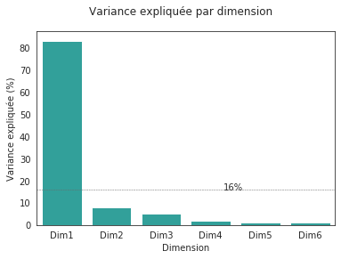

```python
g_eig = seaborn.barplot(x = "Dimension",
                y = "% variance expliquée",
                palette = ["lightseagreen"],
                data = eig)
g_eig.set(ylabel = "Variance expliquée (%)")
g_eig.figure.suptitle("Variance expliquée par dimension")
plt.axhline(y = 16, linewidth = .5, color = "dimgray", linestyle = "--") # 16 = 100 / 6 (nb dimensions)
plt.text(3.25, 16, "16%")
```

```python
wgi_pca = pca.transform(wgi)
# Transformation en DataFrame pandas
wgi_pca_df = pandas.DataFrame({
    "Dim1" : wgi_pca[:,0],
    "Dim2" : wgi_pca[:,1],
    "Pays" : wgi.index,
    "Labels" : db.labels_
})
```

```python
# Résultat (premières lignes)
wgi_pca_df.head()
```

|  | Dim1 | Dim2 | Pays | Labels |
| --- | --- | --- | --- | --- |
| 0 | 3.787545 | -0.937147 | Afghanistan | 0 |
| 1 | 0.016315 | 0.286759 | Albania | 1 |
| 2 | 2.059633 | -0.341831 | Algeria | 1 |
| 3 | -3.389095 | 0.124413 | Andorra | 2 |
| 4 | 2.436206 | 0.227125 | Angola | 1 |

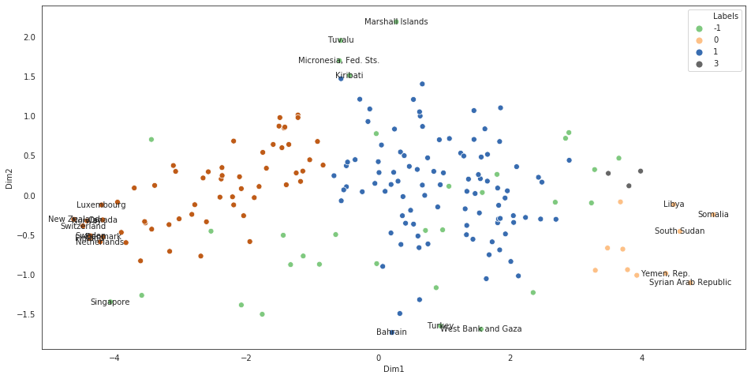

```python
plt.figure(figsize=(16,8))
g_pca = seaborn.scatterplot("Dim1", "Dim2",
                            hue = "Labels", size = "Labels", sizes = (50,50),
                            data = wgi_pca_df, palette = "Accent")
for x, y, v in zip(wgi_pca_df.Dim1, wgi_pca_df.Dim2, wgi_pca_df.Pays):
    if (abs(x) > 4) | (abs(y) > 1.5):
        g_pca.text(x, y, v,
               horizontalalignment='center',
               verticalalignment='center')
```

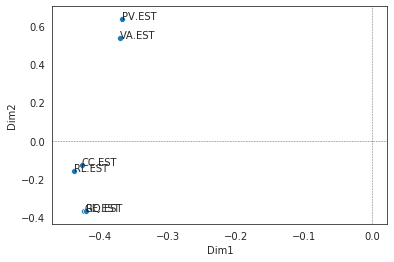

```python
wgi_var = pandas.DataFrame({
    "Dim1" : pca.components_[0, :],
    "Dim2" : pca.components_[1, :],
    "Var" : wgi.columns
})
g_pca = seaborn.scatterplot("Dim1", "Dim2", data = wgi_var)
g_pca.axvline(x = 0, linewidth = .5, color = "dimgray", linestyle = "--")
g_pca.axhline(y = 0, linewidth = .5, color = "dimgray", linestyle = "--")

for x, y, v in zip(wgi_var.Dim1, wgi_var.Dim2, wgi_var.Var):
    g_pca.text(x, y, v)
```

### Variation de `eps`

```python
res = []

for e in [v / 20 for v in range(1, 21)]:
    dbe = DBSCAN(eps = e, min_samples = 3)
    dbe.fit(wgi)
    t = pandas.crosstab(dbe.labels_, "Freq")
    if len(t["Freq"]) == 1:
        nboutliers = t["Freq"]
    else:
        nboutliers = t["Freq"][0]
    res.append({"eps": e, "nb_clusters": len(t) - 1, "nb_outliers": list(t["Freq"])[0]})
res = pandas.DataFrame(res)
print(res)
```

```
     eps  nb_clusters  nb_outliers
0   0.05            0          202
1   0.10            0          202
2   0.15            0          202
3   0.20            0          202
4   0.25            0          202
5   0.30            1          198
6   0.35            5          182
7   0.40            8          167
8   0.45           10          148
9   0.50           12          128
10  0.55           10          117
11  0.60            6           93
12  0.65            6           66
13  0.70            4           50
14  0.75            4           40
15  0.80            4           32
16  0.85            3           23
17  0.90            3           16
18  0.95            2           10
19  1.00            2            9
```

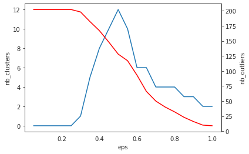

```python
ax = seaborn.lineplot("eps", "nb_clusters", data = res)
ax2 = ax.twinx()
# en rouge les outliers
seaborn.lineplot("eps", "nb_outliers", data = res, color = "red")
```